# Exploratory Data Analysis

MAP 553-Regression

# R Software

**R**, or rather *the **R** project for Statistical Computing*, is a Domain Specific Language extremely used in statistics and more generally in data science. . It can be seen an open-source implementation of **S**, a statistical programming language invented in 1976. It is widely used in both the industrial and the academic world. Its main strength is the huge number of packages available while its main drawback is its in-memory processing design which limits the size of the data it can handle. **R** remains nevertheless a very powerful tools to design a data processing chain.

During the course, we will use **R** and **Rstudio Desktop**. The first step is thus to install those two programs. They are freely available respectively at https://cran.r-project.org/ and https://www.rstudio.com/products/rstudio/download3/ for windows, OS X and Linux. Be sure to install the latest version of **R** and of the free version of **Rstudio Desktop**.

We insist on the importance of litterate programming and reproducible research. Each lab, such as this one, will thus be written with **Rmarkdown** a light markdown language in which one mixes code and explaination. This allows to easily comment and describe our experiments in the same document than the one containing the code. This also helps to be sure that your code is self sufficient by requiring the document to *compile* on its own.

# Exploratory Data Analysis (EDA).

The dataset used by Galton is available in **R** in the package **HistData** which contains several datasets of historical interests. Packages are the extension of **R** that are made available in the easy to use format by its users. The first step for you is to install this package. You only have to do it once as the packages are stored locally. You can either use the *Packages* tab of the lower right panel in **Rstudio** or the command line

```r
install.packages("HistData")
```

We are now ready to look at the dataset: we should *load* first the package with the `library` command, which allows use to look at the first lines of the dataset **GastonFamilies** with the **head** command.

```r
library(HistData)
head(GaltonFamilies)
```

```
##   family father mother midparentHeight children childNum gender childHeight
## 1    001   78.5   67.0           75.43        4        1   male        73.2
## 2    001   78.5   67.0           75.43        4        2 female        69.2
## 3    001   78.5   67.0           75.43        4        3 female        69.0
## 4    001   78.5   67.0           75.43        4        4 female        69.0
## 5    002   75.5   66.5           73.66        4        1   male        73.5
## 6    002   75.5   66.5           73.66        4        2   male        72.5
```

It is organized in a table, called a *dataframe* in **R**, in which each column may have a different type. Using the `glimpse` command of the package **dplyr** (that you should install), we may see what is in this dataframe.

```r
library(dplyr)
glimpse(GaltonFamilies)
```

```
## Rows: 934
## Columns: 8
## $ family          <fct> 001, 001, 001, 001, 002, 002, 002, 002, 003, 003, 004…
## $ father          <dbl> 78.5, 78.5, 78.5, 78.5, 75.5, 75.5, 75.5, 75.5, 75.0,…
## $ mother          <dbl> 67.0, 67.0, 67.0, 67.0, 66.5, 66.5, 66.5, 66.5, 64.0,…
## $ midparentHeight <dbl> 75.43, 75.43, 75.43, 75.43, 73.66, 73.66, 73.66, 73.6…
## $ children        <int> 4, 4, 4, 4, 4, 4, 4, 4, 2, 2, 5, 5, 5, 5, 5, 6, 6, 6,…
## $ childNum        <int> 1, 2, 3, 4, 1, 2, 3, 4, 1, 2, 1, 2, 3, 4, 5, 1, 2, 3,…
## $ gender          <fct> male, female, female, female, male, male, female, fem…
## $ childHeight     <dbl> 73.2, 69.2, 69.0, 69.0, 73.5, 72.5, 65.5, 65.5, 71.0,…
```

You can have more information by using **help**:

```r
help(GaltonFamilies)
```

We have thus 934 observations of 8 variables:

- **family**, a *factor* giving a identifier for each family
- **father**, a **double** giving the height of the father
- **mother**, a **double** giving the height of the mother
- **midparentHeight**, a **double** given by the average of the size of the father and the one of the mother multiplies by $1.08$.
- **children**, an **integer** specifying the number of children within the family
- **childNum**, an **integer** specifying the rank of the child within the family
- **gender**, a **factor** giving the sex of the child
- **childHeight**, a **double** giving the heigth of the child

The types of the columns are explicit, except maybe for the **factor** one. It corresponds to a qualitative variable which has several modalities. The other types of columns you may easily encounter are **ordered factor**, **date**, **characters**, which are pretty much self explaining.

Note that the height has been corrected for the sex in the **midparentHeight** but not in the **childHeight**. We may easily create a new column (variable) **childHeightC** where we apply the same $1.08$ factor to the female individuals. We will rely on the `mutate` command of **dplyr** that allows to modify or create columns in a convenient way.

```r
GaltonFamilies <- mutate(GaltonFamilies,
                         childHeightC = if_else(gender == "male", childHeight,
                                                1.08 * childHeight))
glimpse(GaltonFamilies)
```

```
## Rows: 934
## Columns: 9
## $ family          <fct> 001, 001, 001, 001, 002, 002, 002, 002, 003, 003, 004…
## $ father          <dbl> 78.5, 78.5, 78.5, 78.5, 75.5, 75.5, 75.5, 75.5, 75.0,…
## $ mother          <dbl> 67.0, 67.0, 67.0, 67.0, 66.5, 66.5, 66.5, 66.5, 64.0,…
## $ midparentHeight <dbl> 75.43, 75.43, 75.43, 75.43, 73.66, 73.66, 73.66, 73.6…
## $ children        <int> 4, 4, 4, 4, 4, 4, 4, 4, 2, 2, 5, 5, 5, 5, 5, 6, 6, 6,…
## $ childNum        <int> 1, 2, 3, 4, 1, 2, 3, 4, 1, 2, 1, 2, 3, 4, 5, 1, 2, 3,…
## $ gender          <fct> male, female, female, female, male, male, female, fem…
## $ childHeight     <dbl> 73.2, 69.2, 69.0, 69.0, 73.5, 72.5, 65.5, 65.5, 71.0,…
## $ childHeightC    <dbl> 73.200, 74.736, 74.520, 74.520, 73.500, 72.500, 70.74…
```

Note that `<-` is the prefered assignment operator in **R** (`=` would also work here).

We are now ready to visualize this dataset using the **ggplot2** package (that you should install first). This package allows to produce nice plot with a quite explicit syntax.

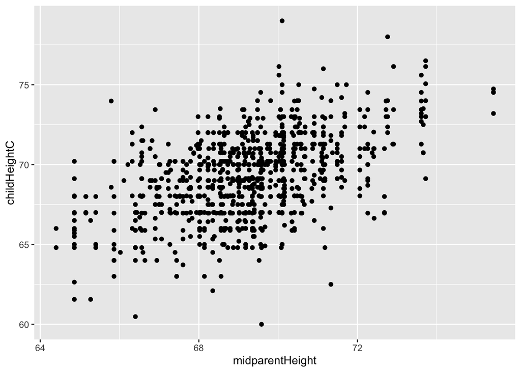

```r
library(ggplot2)
ggplot(data = GaltonFamilies, aes(x = midparentHeight, y = childHeightC)) + geom_point()
```

This representation can be enhanced by adding some transparency to the point so that we can visualize if several children with the same height have the same parent height.

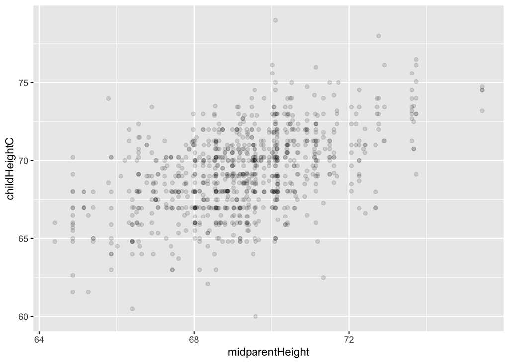

```r
ggplot(data = GaltonFamilies, aes(x = midparentHeight, y = childHeightC)) + geom_point(alpha = .125)
```

If we are interested in the height increment, we can either compute this new variable on the fly or add it explicitely.

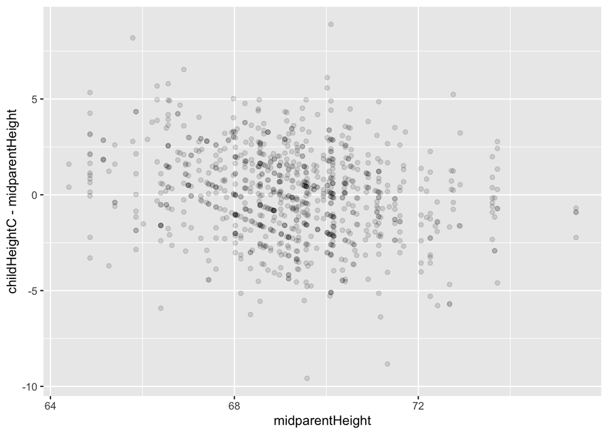

```r
ggplot(data = GaltonFamilies, aes(x = midparentHeight, y = childHeightC - midparentHeight)) + geom_point(alpha = .125)
```

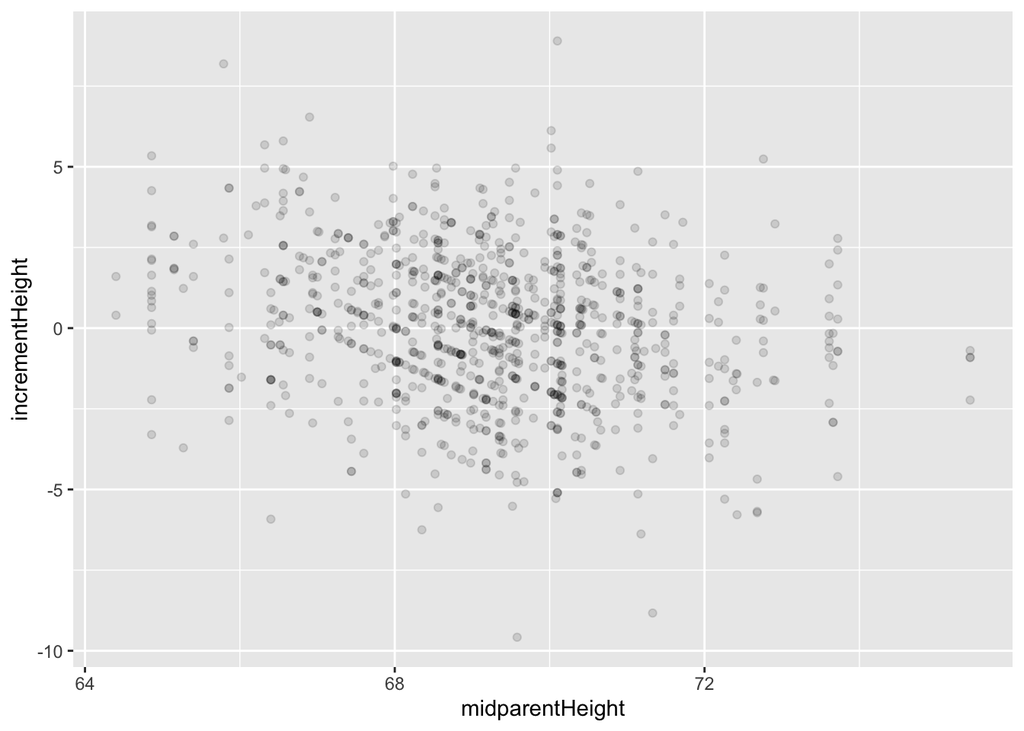

```r
GaltonFamilies <- mutate(GaltonFamilies, incrementHeight = childHeightC - midparentHeight)
ggplot(data = GaltonFamilies, aes(x = midparentHeight, y = incrementHeight)) + geom_point(alpha = .125)
```

# Performing a linear regression

The **R** command `lm` performs a linear regression specified by a *formula* explaining which variable(s) to use and a *dataset*.

For instance,

```r
reg <- lm(childHeightC ~ midparentHeight, data = GaltonFamilies)
```

computes the linear regression of **childHeightC** with respect to **midparentHeight**.

We can see the coefficients by calling directly `reg`.

```r
reg
```

```
##
## Call:
## lm(formula = childHeightC ~ midparentHeight, data = GaltonFamilies)
##
## Coefficients:
##     (Intercept)  midparentHeight
##         19.9175           0.7126
```

**R** automatically computes the variances of each parameter (as well as much more quantities that we will study later). They are available with the **summary** command:

```r
summary(reg)
```

```
##
## Call:
## lm(formula = childHeightC ~ midparentHeight, data = GaltonFamilies)
##
## Residuals:
##     Min      1Q  Median      3Q     Max
## -9.4992 -1.4956  0.0939  1.5365  9.1303
##
## Coefficients:
##                 Estimate Std. Error t value Pr(>|t|)
## (Intercept)     19.91751    2.82130    7.06 3.26e-12 ***
## midparentHeight  0.71258    0.04075   17.49  < 2e-16 ***
## ---
## Signif. codes:  0 '***' 0.001 '**' 0.01 '*' 0.05 '.' 0.1 ' ' 1
##
## Residual standard error: 2.244 on 932 degrees of freedom
## Multiple R-squared:  0.247,  Adjusted R-squared:  0.2462
## F-statistic: 305.8 on 1 and 932 DF,  p-value: < 2.2e-16
```

This gives the estimated values (**estimate**) of the intercept and the slope called respectively **(Intercept)** and **midparentHeight** as well their estimated standard deviations.

We can also use **ggplot2** to visualize the regression. Note that the linear regression is recomputed on the fly here.

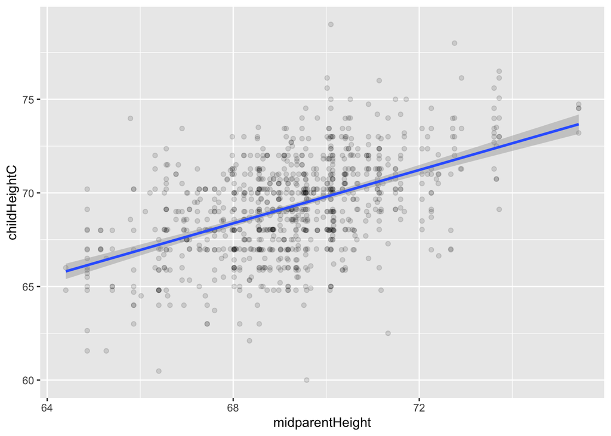

```r
ggplot(data = GaltonFamilies, aes(x = midparentHeight, y = childHeightC)) +
  geom_point(alpha = .125) + geom_smooth(method = "lm")
```

## Exercises

1. Compute the regression of the **incrementHeight** with respect to the **midparentHeight**. How does this result compare to the one obtained previously.
2. Simulation Problem.
   1. Generate $n = 100$ data as follows. Take $X_i \sim \mathrm{Unif}([0,1])$. Then set
      $$Y_i = \beta_0 + \beta_1 X_i+ \epsilon_i,\quad i=1,\ldots,n,$$
      where $\beta_0 = 4$ and $\beta_1 = 2$ and $\epsilon_i \sim N(0,1)$. Plot the data. Fit the regression line. Add the fitted line to the plot.
   2. Repeat the experiment in (a) 1,000 times. You will get a different value of $\widehat\beta_1$ each time. Denote these by $\widehat{\beta}_1^{(1)},\ldots,\widehat{\beta}_1^{(1000)}$. What is the mean of these values? What value do you expect the mean to be? Plot a histogram of $\widehat\beta_1^{(1)},\ldots,\widehat\beta_1^{(1000)}$.
   3. Repeat (b) but now take $\epsilon_i$ to have a Cauchy distribution. How does the histogram change?
3. Load the dataset **airquality** using the R command: **data(airquality)**.
   1. Use the summary command to summarize the data. Use the pairs command to plot scatterplots of all pairs of data.
   2. Plot **Ozone** versus **Solar Radiation**. (Put **Solar** on the $x$-axis.) Describe the rela- tionship between these variables.
   3. Fit a least squares regression line. Add the line to the plot and report the intercept and slope.
   4. Compute the residuals $\epsilon_i = Y_i - (\widehat{\beta}_0 + \widehat{\beta}_1 X_i)$. Plot the residuals versus the $X_i$’s. Does it appear that the standard linear regression model assumptions hold?